# sympy_lesson

sympyについて解説して。

シンボリケル(Sympy)は、Pythonで数値や式を扱うために使用できるライブラリです。数式の計算や、微積分などの高级数学機能に対応しています。

### 安心して使える環境

Pythonと同様に、Sympyも簡単な構成で実行できます。特定の機能を使用したい場合には、Pythonの解像策を参考に調べることで便利です。

### Sympyの基本的な用途

1.数値の操作:数値の積や和などの演算を行うために使用される。 2.式の評価:式を評価し結果を取得する。 3.微積分:微積分を扱うためのライブラリ機能。微積分によって得られる関数の導関数を計算することができます。 4.多項式の操作:多項式の因数分解、根の検索などを手軽に実行できる。

### Sympyの特徴

1.簡単な構成:Pythonと同様にシンプルで便利です。簡単に学べるため、初心者でも使いやすいことにも注意してください。 2.機能多度:数式を扱う際には、微積分、多項式の操作など、いろいろな機能があります。

[sympy仕様](https://www.sympy.org/en/index.html)

```python
import sympy as sp
import pprint as pp
# Define the symbols
x, y = symbols('x y')
f = sp.log(x**2 + y**2)
res=sp.diff(f, x)
print(res)
print(sp.integrate(res, x))
```

```
2*x/(x**2 + y**2)
log(x**2 + y**2)
```

```python
from sympy import symbols, Matrix,sin, init_printing
import numpy as np
import matplotlib.pyplot as plt
import pprint as pp
# Define the symbols
x, y = symbols('x y')

# Define the function
f = x**2 + y**2

# Compute the gradient
grad_f = Matrix([f]).jacobian([x, y])
print(grad_f)

# ベクトル関数（f1, f2）の定義
f = Matrix([x**2 + y, x * y])

# ヤコビアン行列の計算
J = f.jacobian([x, y])

print(J)

y = sin(x).diff(x).diff(x)
print(y)


# ベクトルの定義
v1 = Matrix([1, 2, 3])
v2 = Matrix([[4, 5, 6],[7, 8, 9]])
#v2 = Matrix([4, 5, 6])

print(v1)
print(v2)

pp.pprint(v1)
pp.pprint(v2)

display(v1)
display(v2)

v = Matrix([[1, 2, 3]])
display(v)

# 行列の定義
A = Matrix([[1, 2, 3], [4, 5, 6]])
display(A)
# 転置
A_T = A.T

display(A_T)

c1,c2,c3 = symbols('c1 c2 c3')
# ベクトルの定義
v = Matrix([[0, -c3, c2],[c3,0,-c1],[-c2,c1,0]])
display(v)
display(v * v.T)
```

```
Matrix([[2*x, 2*y]])
Matrix([[2*x, 1], [y, x]])
-sin(x)
Matrix([[1], [2], [3]])
Matrix([[4, 5, 6], [7, 8, 9]])
Matrix([
[1],
[2],
[3]])
Matrix([
[4, 5, 6],
[7, 8, 9]])
```

$\displaystyle \left[\begin{matrix}1\\2\\3\end{matrix}\right]$

$\displaystyle \left[\begin{matrix}4 & 5 & 6\\7 & 8 & 9\end{matrix}\right]$

$\displaystyle \left[\begin{matrix}1 & 2 & 3\end{matrix}\right]$

$\displaystyle \left[\begin{matrix}1 & 2 & 3\\4 & 5 & 6\end{matrix}\right]$

$\displaystyle \left[\begin{matrix}1 & 4\\2 & 5\\3 & 6\end{matrix}\right]$

$\displaystyle \left[\begin{matrix}0 & - c_{3} & c_{2}\\c_{3} & 0 & - c_{1}\\- c_{2} & c_{1} & 0\end{matrix}\right]$

$\displaystyle \left[\begin{matrix}c_{2}^{2} + c_{3}^{2} & - c_{1} c_{2} & - c_{1} c_{3}\\- c_{1} c_{2} & c_{1}^{2} + c_{3}^{2} & - c_{2} c_{3}\\- c_{1} c_{3} & - c_{2} c_{3} & c_{1}^{2} + c_{2}^{2}\end{matrix}\right]$

```python
from sympy.algebras.quaternion import Quaternion

# クオータニオン q = a + bi + cj + dk を定義
q = Quaternion(1, 2, 3, 4)

display(q)

q1 = Quaternion(1, 2, 3, 4)
q2 = Quaternion(5, 6, 7, 8)

# 四元数の加算・減算
q_sum = q1 + q2
q_diff = q1 - q2

display("加算:", q_sum)
display("減算:", q_diff)


theta = sp.pi / 2  # 90度
rotation_q = Quaternion(sp.cos(theta/2), sp.sin(theta/2), 0, 0)  # X軸回転

v3 = Quaternion(0, 1, 1, 1)
v3_r = rotation_q * v3 *  rotation_q.conjugate()

display(f'answer={5*6}')

#display(rotation_q)
7*8
```

$\displaystyle 1 + 2 i + 3 j + 4 k$

```
'加算:'
```

$\displaystyle 6 + 8 i + 10 j + 12 k$

```
'減算:'
```

$\displaystyle \left(-4\right) + \left(-4\right) i + \left(-4\right) j + \left(-4\right) k$

```
'answer=30'
```

$\displaystyle 56$

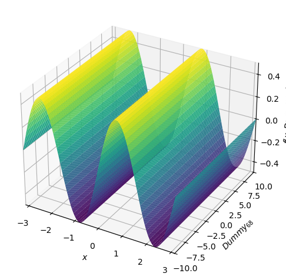

```
<sympy.plotting.backends.matplotlibbackend.matplotlib.MatplotlibBackend at 0x13228dc70>
```

```python
from sympy.plotting import plot,plot3d
from sympy import sin, cos,symbols, pi

plot3d(sin(x)*cos(x), (x, -pi, pi), adaptive=True, line_color=lambda a: sin(a))
```

```python
from sympy import symbols, inverse_laplace_transform, exp

# シンボル変数の定義
t, s = symbols('t s')

# ラプラス変換された関数
F = 1 / (s + 1)

# ラプラス逆変換を計算
f_t = inverse_laplace_transform(F, s, t)

print("ラプラス逆変換:", f_t)
```

```
ラプラス逆変換: exp(-t)*Heaviside(t)
```